# Exercise 5.9 - 5.10 - Investing in stock with data

Prior model for Exercise 5.9 + Updating with data (5.10)

Dana Kozáková

2025-10-24

## Úvod

Riešenie cvičenia 5.9 z knihy [Bayes Rules!](https://www.bayesrulesbook.com/chapter-5#exercises-4) Modelovanie ceny investície počas dňa normálnym rozdelením  
a cvičenia 5.10 z rovnakej knihy Update apriórneho modelu o dáta

## Exercise 5.9: Investing in Stock

> You just bought stock in FancyTech. Let random variable $\mu$, be the average dollar amount that your FancyTech stock goes up or down in a one-day period. At first, you believe that $\mu$ is 7.2 dollars with a standard deviation of 2.6 dollars.  
> a. Tune and plot an appropriate Normal prior model for$\mu$.  
> b. According to your plot, does it seem plausible that the FancyTech stock would increase by an average of 7.6 dollars in a day?  
> c. Does it seem plausible that the FancyTech stock would increase by an average of 4 dollars in a day?  
> d. What is the prior probability that, on average, the stock price goes down? Hint: `pnorm()`.  
> e. What is the prior probability that, on average, your stock price goes up by more than 8 dollars per day?

## Solution:

### a. Apriórny model Normal pre $\mu$

Na začiatku veríme, že stredná hodnota je 7.2 a odchýlka 2.6. To sú teda parametre apriórneho normálneho modelu. Smerodajná odchýlka vyjadruje našu neistotu ohľadom strednej hodnoty.  
**Hyperparametre:** $\theta$ = apriorna stredná hodnota pre $\mu$  
$\tau$ = apriórna smerodajná odchýlka (miera neistoty v odhade $\mu$)

> $$\begin{equation}
> \begin{split}
> \mu \sim N(\theta = 7.2, \tau^2 = 2.6^2)
> \end{split}
> \end{equation}$$

#### Graf - apriórny model:

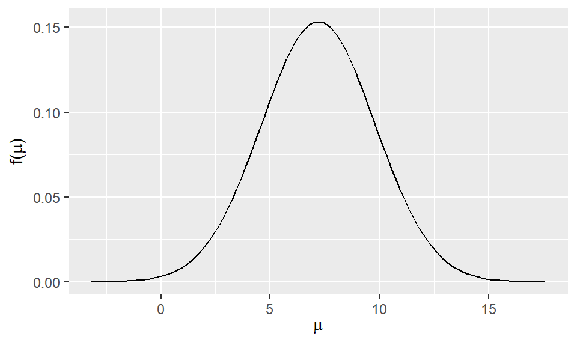

### b. Vierohodnosť hodnoty 7.6

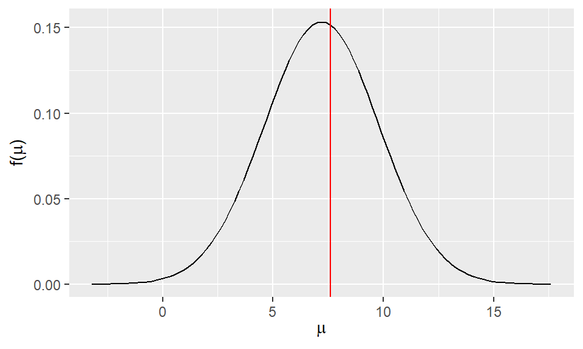

```
## Výška krivky v bode 7.6 je 0.1516342
##  Výška krivky v strednej hodnote je 0.1534393
##  Vzdialenosť hodnoty 7.6 od strednej hodnoty je 0.1538462 -násobok smerodajnej odchýlky.
```

Hodnota 7.6 je blízko strednej hodnoty 7.2. Je teda vysoko vierohodná.

### c. Vierohodnosť hodnoty 4

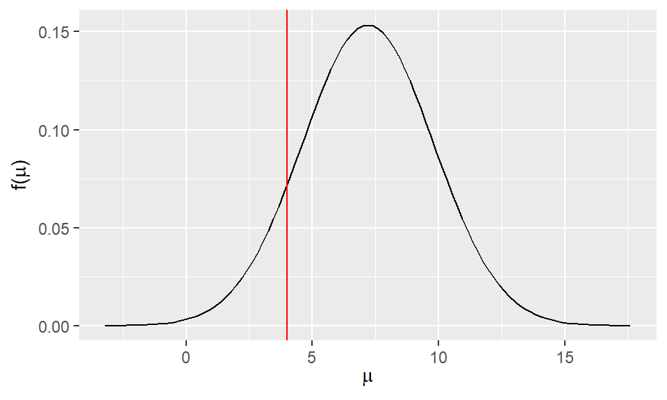

```
## Výška krivky v bode 4 je 0.0719455
```

```
## Výška krivky v strednej hodnote je 0.1534393
```

```
## Vzdialenosť hodnoty 4 od strednej hodnoty je 1.230769-násobok smerodajnej odchýlky.
```

Hodnota 4 je ďalej od strednej hodnoty 7.2. Je teda oveľa menej vierohodná.

### d. Pravdepodobnosť poklesu

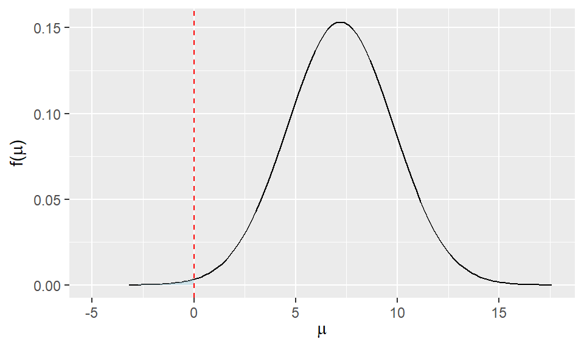

```
## Pravdepodobnosť, že cena bude klesať je 0.0028
```

### e. Pravdepodobnosť rastu o viac ako 8

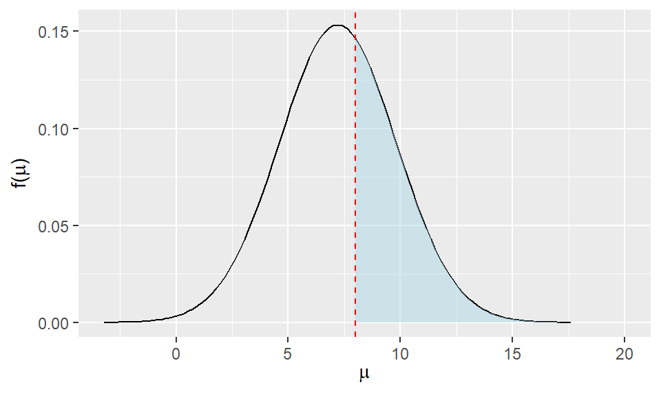

```
## Pravdepodobnosť, že cena bude rásť o viac ako 8 je 0.3792
```

## Exercise 5.10: Investing in Stock with data

> Continuing with Exercise 5.9, it’s reasonable to assume that the daily changes in FancyTech stock value are Normally distributed around an unknown mean of $\mu$ with a known standard deviation of $\sigma = 2$ dollars. On a random sample of 4 days, you observe changes in stock value of $-0.7$, $1.2$, $4.5$, and $-4$ dollars.  
> a. Plot the corresponding likelihood function of $\mu$.  
> b. Plot the prior pdf, likelihood function, and the posterior pdf for $\mu$.  
> c. Use ‘summarize_normal_normal()’ to calculate descriptive statistics for the prior and the posterior models.  
> d. Comment on how your understanding about $\mu$ evolved from the prior (in the previous exercise) to the posterior based on the observed data.  
> e. What is the posterior probability that, on average, the stock price goes down? Hint: `pnorm()`.  
> f. What is the posterior probability that, on average, your stock price goes up by more than 8 dollars per day?

## Solution:

### a. Vierohodnostný model pre $\mu$

#### Dáta: 4 pozorovania na burze

```r
y <- c(-0.7, 1.2, 4.5, -4)
sd <- 2
```

> Neznámy hyperparameter $\mu$ má normálne rozdelenie.
> $$\begin{equation}
> \begin{split}
> \mu \sim N(\theta = 7.2, \tau^2 = 2.6^2)
> \end{split}
> \end{equation}$$

> Za predpokladu, že poznáme $\mu$, tak zmenu ceny na burze modelujeme normálnym rozdelením. T.j. vierohodnostná funkcia je:
> $$\begin{split}
> Y | \mu & {\sim} N(\mu, \sigma^2) \\
> \end{split}$$

> Označme ($Y_1$,$Y_2$,,$Y_n$) zmeny na burze v jednotlivých pozorovaných dňoch. Zmena ceny za jeden deň je **nezávisle** modelovaná normálnym modelom.
> $$\begin{split}
> Y_i | \mu & \stackrel{ind}{\sim} \text{N}(\mu, \sigma^2) \\
> \end{split}$$

> Neanalyzujeme však každý deň samostatne, využijeme súhrnnú informáciu zo všetkých dní, t.j. máme funkciu združenej hustoty pravdepodobnosti:  
> **Združená hustota pravdepodobnosti**
> - Nech $(Y_1,Y_2,\ldots,Y_n)$ sú nezávislé pozorovania náhodnej premennej a $\vec{y} = (y_1,y_2,\ldots,y_n)$ je vektor týchto pozorovaní
> - $f(y_i | \mu)$ označuje funkciu hustoty pre jedno pozorovanie $Y_i$.

> Za predpokladu nezávislosti potom možeme napísať združenú funkciu hustoty pre vektor zistených dát:
> $$\begin{equation}
> f(\vec{y} | \mu) = \prod_{i=1}^{n}f(y_i|\mu) =
> \prod_{i=1}^{n}\frac{1}{\sqrt{2\pi\sigma^2}}\exp\bigg[{-\frac{(y_i-\mu)^2}{2\sigma^2}}\bigg]
> \end{equation}$$

> Teda máme vierohodnostnú funkciu pre $\mu$ (tá je rovnaká ako združená hustota, líši sa len pochopením parametra)
> $$\begin{equation}
> L(\mu |\vec{y}) \propto \prod_{i=1}^{n}
> \exp\bigg[{-\frac{(y_i-\mu)^2}{2\sigma^2}}\bigg]
> = \exp\bigg[{-\frac{\sum_{i=1}^n(y_i-\mu)^2}{2\sigma^2}}\bigg]
> \end{equation}$$

> Po zjednodušení s využitím $y$ (priemer $y_i$) a $n$ (počet) dostávame proporcionálnu funkciu k vierohodnostnej:
> $$\begin{equation}
> L(\mu | \vec{y}) \propto
> \exp\bigg[{-\frac{(\bar{y}-\mu)^2}{2\sigma^2/n}}\bigg] \;\;\;\; \text{
> for } \; \mu \in (-\infty, \infty)
> \end{equation}$$

#### Graf pre vierohodnostnú funkciu (likehood)

Graf zobrazuje (neškálovanú) vierohodnosť získaných dát za predpokladu, že by parameter $\mu$ bol postupne z intervalu približne [-4; 4]

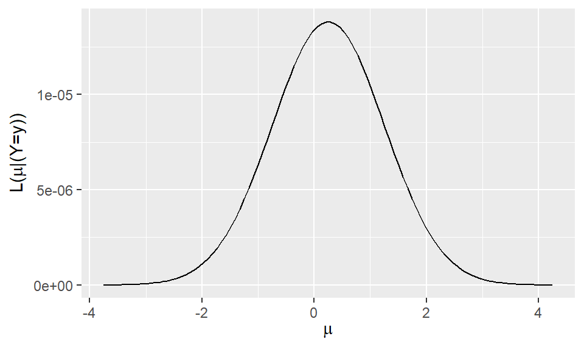

```r
# Vierohodnostná funkcia
plot_normal_likelihood(y = y, sigma = sd) # odchylku neodhadujeme, je urcena vopred
```

Pre naše dáta:

```
## Známa odchýlka sigma: 2
## Priemer pozorovaných hodnôt: 0.25, počet pozorovaných hodnôt: 4
```

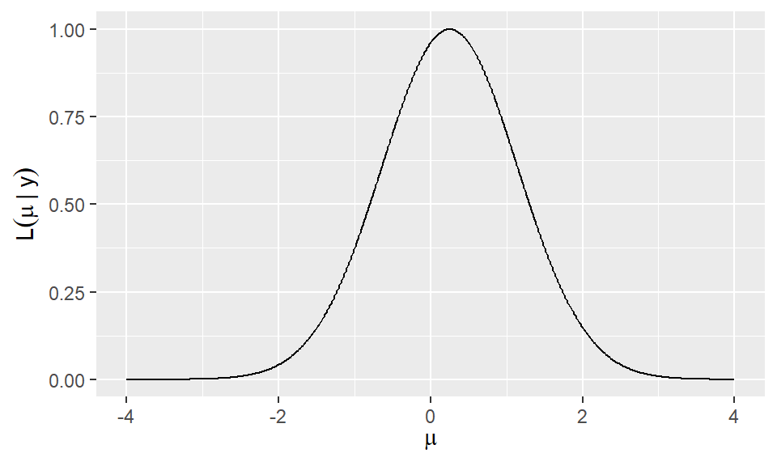

```r
# Vierohodnostná funkcia podla vzorca
xl <- seq(from = -4, to = 4, length = 501)
yl <- exp(-(0.25-xl)^2/1.6)
df <- data.frame(xl, yl)
ggplot(data = df, mapping = aes(x = xl, y = yl)) +
  geom_line() +
  labs(x = expression(mu), y = expression(L(mu~"|"~y)))
```

### b. Vykresliť priorné pdf, vierohodnostnú funkciu a posteriorné pdf pre $\mu$

**Posteriorný model** Posteriorny model je proporcionálny súčinu apriorneho modelu a vierohodnostného modelu:

> Jednotlivé pozorovania majú normálne rozdelenie:
> $$\begin{split}
> Y_i | \mu \; \sim \; N(\mu, \sigma^2) \\
> \end{split}$$

> Na základe apriórneho modelu a pozorovania dát –> posteriórny Normal model:
> $$\begin{equation}
> \mu|\vec{y} \; \sim \; N\bigg(\theta\frac{\sigma^2}{n\tau^2+\sigma^2} +
> \bar{y}\frac{n\tau^2}{n\tau^2+\sigma^2}, \;
> \frac{\tau^2\sigma^2}{n\tau^2+\sigma^2}\bigg)
> \end{equation}$$
> kde $\overline{y}$ je priemernou hodnotou poZorovaní $\vec{y} = (y_1,y_2,\ldots,y_n)$

#### Graf pre apriórný, vierohodnostný aj posteriórny model

V grafe vidíme rozdelenia všetkých troch modelov.

[figure not shown]

```r
# Zobrazenie prioru, vierohodnosti a posterioru
  # theta, tau - from prior
  # sd - supposed to be constant
  # y_bar, n - from data
plot_normal_normal(mean = theta, sd = tau, sigma = sd, y_bar = mean(y) , n = length(n))
```

#### Posteriórny model pre naše dáta podľa vzorca

```
## Vypočítaná stredná hodnota pre posterior podľa vzorca: 1.145619
## smerodajná odchýlka: 0.9333456
```

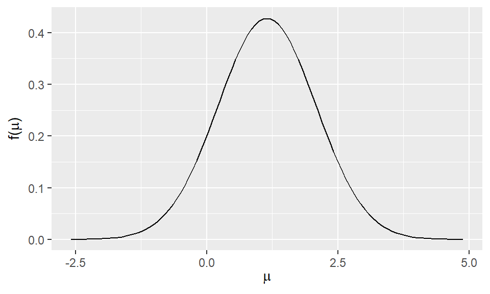

### c. Porovnať charakteristiky apriórneho a posteriórneho modelu

```
##       model     mean     mode      var        sd
## 1     prior 7.200000 7.200000 6.760000 2.6000000
## 2 posterior 1.145619 1.145619 0.871134 0.9333456
```

```
## Váha strednej hodnoty z priórneho modelu je: 0.128866
## váha strednej hodnoty z dát je: 0.871134
```

### d. Zhodnotenie výsledkov

Na začiatku sme predpokladali, že priemerná zmena akcie je 7,2+-2,6. Avšak pozorované dáta majú priemer len 0,25. Preto sa stredná hodnota aposteriórnej hustoty výrazne posunula doľava do 1,146. Posteriórny model je váženým priemerom priórnej hustoty a dát. Váha apriórnej strednej hodnoty je oveľa nižšia ako z dát, preto je posteriórna stredná hodnota bližšia k dátovej.

### e. Pravdepodobnosť poklesu pre posteriórny model

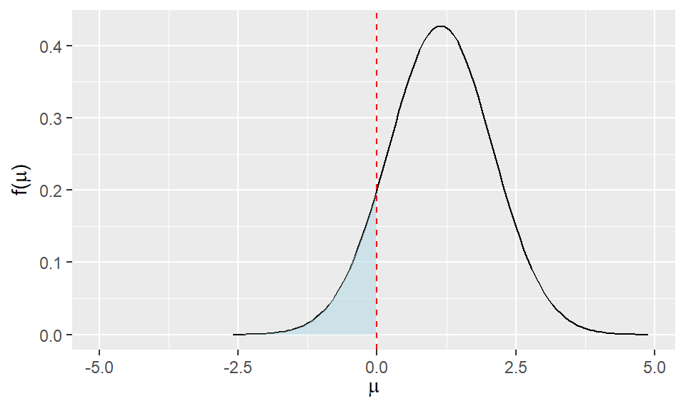

```
## Pravdepodobnosť poklesu:
## Pôvodne:  0.0028
## Teraz 0.1098
```

### f. Pravdepodobnosť rastu o viac ako 8 pre posteriórny model

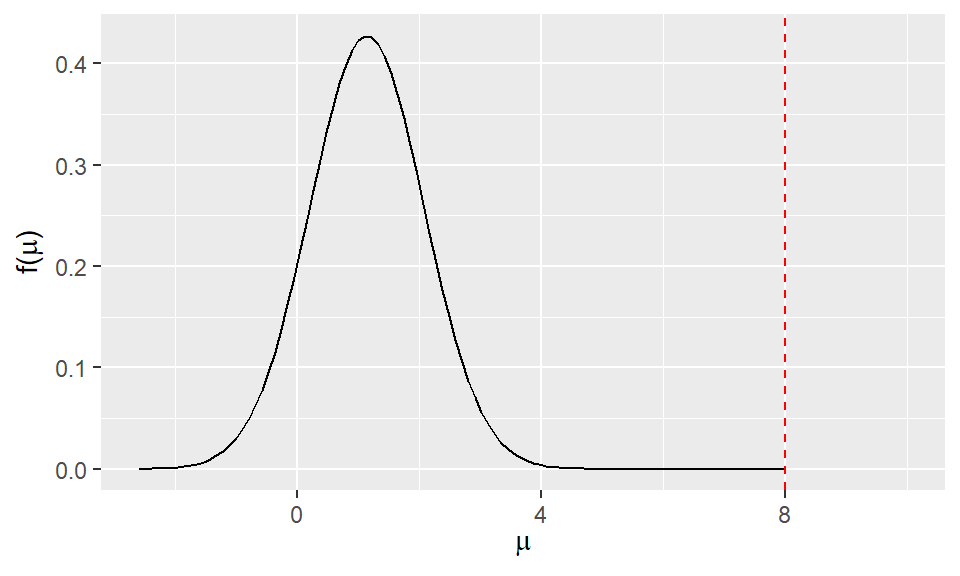

```
## Pravdepodobnosť rastu o viac ako 8:
## Pôvodne:  0.3792
## Teraz 0
```